# Module 2

[figure not shown]

# Module 2: Strategies to make your private data shareable

There are two recommended strategies for publicly sharing data that protect private information:

- De-identify data in whole or in part
- Create synthetic data mimicking the original

Follow the instructions below to de-identify or create synthetic data. Once you have de-identified or created synthetic data, share it publicly through GitHub by following the steps in our GitHub module.

## How to de-identify data

**De-identified data** is data with personally identifiable information (PII) removed so that there is not enough information to identify any individual person. Professionals in public health and related fields are concerned with one type of PII, **protected health information (PHI).**

The U.S. Department of Health and Human Services (HHS) provides [guidance on de-identifying data files](https://www.hhs.gov/hipaa/for-professionals/privacy/special-topics/de-identification/). According to the HHS, there are two ways to de-identify data so that it does not included PHI: **safe harbor** and **expert determination**. **Safe harbor** is the removal of specific identifying information from each record, while **expert determination** is the use of statistical methods to de-identify data such as finding and removing unique cases that are identifiable. [Data that are de-identified by one of these two methods are no longer restricted for use or disclosure by the HIPAA Privacy Rule because they no longer contain PHI](https://www.hhs.gov/hipaa/for-professionals/privacy/special-topics/de-identification/#standard).

The **safe harbor** method requires removal from the data source of the following for the individual *and their relatives, employers, or household members*:

1. Names
2. Geographic regions smaller than a state
3. Dates other than year
4. Telephone numbers
5. Fax numbers
6. Email addresses
7. Social security numbers
8. Medical record numbers
9. Health plan beneficiary numbers
10. Account numbers
11. Certificate/license numbers
12. Vehicle identifiers and serial numbers, including license plate numbers
13. Device identifiers and serial numbers
14. Web universal resource locators (URLs)
15. Internet protocol (IP) addresses
16. Biometric identifiers, including finger and voice prints
17. Full-face photographs and any comparable images
18. Any other unique identifying number, characteristic, or code

The **expert determination** method requires that information in the data cannot be used to identify individuals by someone with skills and knowledge of common analytic methods and access to other reasonably available data (e.g., voter registration records). A more detailed description of this method is available on the [HHS website](https://www.hhs.gov/hipaa/for-professionals/privacy/special-topics/de-identification/#standard).

We strongly recommend visiting the [HHS page](https://www.hhs.gov/hipaa/for-professionals/privacy/special-topics/de-identification/#standard) before sharing your de-identified data to ensure you meet either the **safe harbor** or the **expert determination** requirements for de-identification.

We also strongly encourage you to check with your Institutional Review Board before making de-identified data public to ensure you are meeting any requirements to protect human subjects.

## How to create synthetic data

When de-identification is difficult, impossible, or not ideal, create synthetic data that keeps important variables and relationships from the original data. Similar in concept to imputation, creating synthetic data entails replacing some or all observations using appropriate probability distributions to ensure important properties and relationships are maintained [Nowok wt al 2016;Shepherd et al 2017].

There are resources available for most common statistical packages that describe how to create a synthetic data set.

### R

As one example, the `synthpop` package in R can be used to create a synthetic data set. Using the publicly available National Health and Nutrition Examination Survey (NHANES), here is an example of creating a synthetic data set in R:

```r
#bring in the original data name it nhanes
#this is the 2011-2012 NHANES data available from the
#Centers for disease control and prevention
library(RNHANES)
nhanes <- nhanes_load_data("AUQ_G", "2011-2012", demographics = TRUE)

#make a smaller version of nhanes with the variables of interest
vars <- c("RIAGENDR","RIDAGEYR","RIDRETH1")
nhanes.small <- nhanes[,vars]

#open the synthpop library (install first)
library(synthpop)

#create nhanes.synth with default method
#use seed value for reproducibility
nhanes.synth.list <- syn(nhanes.small, seed=123456)
```

```
syn  variables
1    RIAGENDR RIDAGEYR RIDRETH1
```

```r
nhanes.synth <- nhanes.synth.list$syn

#example of comparing the original and synthetic data sets
#add labels to gender and ethnicity variables
#see codebook if needed
nhanes.small$RIAGENDR <- factor(nhanes.small$RIAGENDR,
                                levels = c(1,2),
                                labels = c("Male", "Female"))
nhanes.small$RIDRETH1 <- factor(nhanes.small$RIDRETH1,
                                levels = c(1,2,3,4,5),
                                labels = c("Mexican American", "Other Hispanic",
                                           "Non-Hispanic White", "Non-Hispanic Black",
                                           "Other Race - Including Multi-Racial"))
nhanes.synth$RIAGENDR <- factor(nhanes.synth$RIAGENDR,
                                levels = c(1,2),
                                labels = c("Male", "Female"))
nhanes.synth$RIDRETH1 <- factor(nhanes.synth$RIDRETH1,
                                levels = c(1,2,3,4,5),
                                labels = c("Mexican American", "Other Hispanic",
                                           "Non-Hispanic White", "Non-Hispanic Black",
                                           "Other Race - Including Multi-Racial"))

#original
table(nhanes.small$RIDRETH1, nhanes.small$RIAGENDR)
```

```
                                      Male Female
  Mexican American                     645    619
  Other Hispanic                       496    536
  Non-Hispanic White                  1449   1411
  Non-Hispanic Black                  1273   1315
  Other Race - Including Multi-Racial  800    820
```

```r
#synth
table(nhanes.synth$RIDRETH1, nhanes.synth$RIAGENDR)
```

```
                                      Male Female
  Mexican American                     663    606
  Other Hispanic                       498    550
  Non-Hispanic White                  1468   1403
  Non-Hispanic Black                  1229   1326
  Other Race - Including Multi-Racial  793    828
```

The top table shows the original data frequencies for each category of race/ethnicity across the male and female sex categories. The bottom shows the same variables in the synthetic data set. While the two data sets are not identical, they are similar.

### SPSS

In SPSS, the `SIMPLAN` and `SIMRUN` functions can create synthetic data based on a real dataset. Let’s save the small NHANES data created in the R example above and walk through an example.

```r
# Load haven library, which allows saving files to SPSS format
library(haven)
write_sav(nhanes.small, "C:/Your/Directory/NHANESorig.sav")
```

Run the following in an SPSS syntax editor:

* Open NHANES data saved out from R.  
GET FILE = 'C:\Your\Directory\NHANESorig.sav'.  
DATASET NAME orig.  
DATASET ACTIVATE orig.  
* Add variable labels.

VARIABLE LABELS  
RIAGENDR 'Gender'  
RIDAGEYR 'Age'  
RIDRETH1 'Ethnicity'.

* Create simulation plan based on original NHANES data.  
* Set boundaries for age to range for real data.  
* N = 9364, so set that as maxcases.

SIMPLAN CREATE  
/SIMINPUT INPUT = RIAGENDR RIDRETH1  
/SIMINPUT INPUT = RIDAGEYR MINVAL = 1 MAXVAL = 80  
/CONTINGENCY MULTIWAY = YES  
/STOPCRITERIA MAXCASES = 9364  
/PLAN FILE = 'C:\Your\Directory\NHANES.splan'.

* Run the simulation.

SIMRUN  
/PLAN FILE = 'C:\Your\Directory\NHANES.splan'  
/CRITERIA REPRESULTS = TRUE SEED = 10  
/OUTFILE FILE = 'C:\Your\Directory\NHANESsynth.sav'.

* Open simulated file and take a look.  
GET FILE = 'C:\Your\Directory\NHANESsynth.sav'.  
DATASET NAME synth.  
DATASET ACTIVATE synth.

Default procedures for the `SIMPLAN` command will automatically determine the best-fitting distributions for each variable included in the `SIMINPUT` subcommands, retain correlations between scale variables, and stop after 100,000 cases have been generated. A few modifications have been made for this data set:

1. Simulated values for age were beyond the human lifespan with default settings, so minimum and maximum values were set based on the age range in the real data. SPSS might throw a warning, but it does produce the desired result.
2. SPSS does not automatically retain relationships between categorical variables. Specifying the `CONTINGENCY` subcommand will make that happen.
3. Given the large influence that sample size has on significance testing, manually limiting the maximum number of cases to the size of the real data is recommended using the `STOPCRITERIA` subcommand.

The `SIMRUN` command uses the plan created with `SIMPLAN`, applies it to the original data, and creates the simulated dataset. To ensure the same result each time the plan is applied, specify the `CRITERIA` subcommand as shown with the same seed.

Go to `Help --> Topics` and search for `SIMPLAN` and `SIMRUN` for more specification details and options.

* Compare original and synthetic data on ethnicity/gender.  
DATASET ACTIVATE orig.

CROSSTABS  
/TABLES=RIDRETH1 BY RIAGENDR  
/CELLS=COUNT.

DATASET ACTIVATE synth.

CROSSTABS  
/TABLES=RIDRETH1 BY RIAGENDR  
/CELLS=COUNT.

Original data:

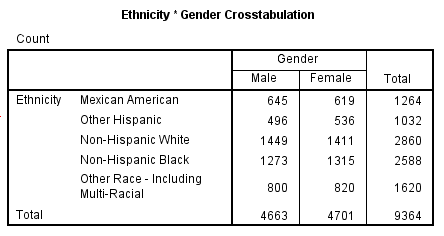

Simulated data:

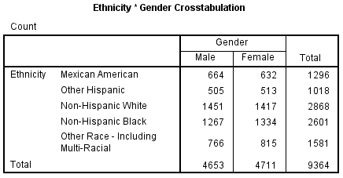

While not exact, the simulated data show patterns similar to the original data.

**A note of caution:** SPSS can maintain relationships between scale variables and between categorical variables, but relationships between scale and categorical, say, age and gender, cannot easily be maintained. If you intend to simulate data that maintain these relationships, your best bet is to convert to R, use `synthpop` as described above, and then back-convert to SPSS.

## Resources

- [Simulating some synthetic data (R)](https://www.r-bloggers.com/simulating-some-synthetic-data/)
- [synthpop: Bespoke Creation of Synthetic Data in R](https://www.jstatsoft.org/article/view/v074i11/v74i11.pdf)
- [OpenSDP (Synthetic data in R)](https://opensdp.github.io/data/)
- [Creating simulated datasets (SPSS)](http://www.statisticalassociates.com/simulateddata.pdf)
- [Using SPSS’s SIMPLAN to generate fake data](https://andrewpwheeler.wordpress.com/2014/04/15/using-spsss-simplan-to-generate-fake-data/)
- [Generating realistic synthetic test dat using SAS random functions](https://www.sas.com/content/dam/SAS/en_ca/User%20Group%20Presentations/TASS/kari_generating_test_data.pdf)
- [Codebook cookbook: A gude to writing a good codebook for data analysis projects in medicine](http://www.medicine.mcgill.ca/epidemiology/joseph/pbelisle/CodebookCookbook/CodebookCookbook.pdf)
- [Review the codebook](https://uc-r.github.io/data_wrangling/codebook)